# Salt × CNT priming in Barley and Cowpea

Synthetic-data demonstration of an analysis pipeline

May 2026

## Background

This is a **portfolio piece** demonstrating an analysis pipeline for a factorial plant stress-physiology experiment. The example scenario is a two-factor design — a NaCl salinity gradient crossed with a seed-priming treatment (labelled *CNT*) — measured in two crop species, **barley** and **cowpea**.

**The data are fully synthetic** (`R/01_simulate_data.R`). The simulation encodes the qualitative phenotype the seed-priming literature reports:

- NaCl monotonically suppresses germination and seedling growth and inflates antioxidant enzymes (SOD, CAT, APX), MDA, proline and H₂O₂.
- MWCNT priming (50 mg L⁻¹) partially rescues germination and growth and lowers damage markers, while *further* up-regulating antioxidant enzymes (priming hypothesis).
- Cowpea is parameterised as more salt-sensitive than barley.

The report layout: percentage germination → univariate seedling growth → ANOVA on growth → per-species PCA on the three growth indices (**barley**, **cowpea**), each shown as a correlation circle plus a treatment biplot.

The point of the repo is not to discover anything — the effect is baked in — it is to demonstrate the **R analysis workflow**.

```r
src <- "data/synthetic.csv"
if (!file.exists(src)) source("R/01_simulate_data.R")

df <- read.csv(src, stringsAsFactors = FALSE)
df$nacl <- factor(df$nacl, levels = c(0, 50, 100, 150))
df$cnt  <- factor(df$cnt,  levels = c("CNT-", "CNT+"))
df$species <- factor(df$species, levels = c("Barley", "Cowpea"))

dim(df)
```

```
## [1] 96 15
```

```r
head(df)
```

|  | species | nacl | cnt | rep | shoot_length_cm | root_length_cm | fresh_weight_g | shoot_root_axis_weight_mg | MDA_nmol_gFW | H2O2_umol_gFW | SOD_U_mg | CAT_U_mg | APX_U_mg | proline_umol_gFW | treatment |
| --- | --- | --- | --- | --- | --- | --- | --- | --- | --- | --- | --- | --- | --- | --- | --- |
| 1 | Barley | 0 | CNT- | 1 | 30.30321 | 14.407067 | 1.852290 | 546.3271 | 8.323415 | 1.187265 | 44.83687 | 14.87221 | 14.42211 | 0.3969897 | NaCl0_CNT0 |
| 2 | Cowpea | 0 | CNT- | 1 | 30.19218 | 17.400978 | 1.600004 | 508.4024 | 7.893343 | 1.276314 | 39.09039 | 11.41379 | 9.07144 | 0.4633654 | NaCl0_CNT0 |
| 3 | Barley | 50 | CNT- | 1 | 24.27828 | 11.291478 | 1.545120 | 498.8484 | 15.622354 | 1.818211 | 65.29456 | 20.47201 | 20.22285 | 1.1693874 | NaCl50_CNT0 |
| 4 | Cowpea | 50 | CNT- | 1 | 23.97096 | 12.592063 | 1.588119 | 405.8820 | 16.107598 | 1.822258 | 62.48289 | 22.46985 | 14.66587 | 1.2721573 | NaCl50_CNT0 |
| 5 | Barley | 100 | CNT- | 1 | 21.73199 | 10.527041 | 1.414204 | 366.6989 | 15.767273 | 2.712533 | 87.27493 | 38.04229 | 25.51614 | 2.3011792 | NaCl100_CNT0 |
| 6 | Cowpea | 100 | CNT- | 1 | 19.02722 | 8.506181 | 1.276199 | 350.4773 | 22.870124 | 3.288496 | 98.40536 | 33.93886 | 18.68509 | 2.2062634 | NaCl100_CNT0 |

96 plants: 2 species × 4 NaCl levels × 2 CNT levels × 6 reps.

## Percentage germination

A separate seed-germination experiment (4 dishes × 25 seeds per treatment cell) covering an extended salt range (0 – 300 mM NaCl) to locate the tolerance limit for each species. Cumulative germination percentage is recorded daily from Day 0 to Day 4.

```r
src_g <- "data/germination.csv"
if (!file.exists(src_g)) source("R/02_simulate_germination.R")

germ <- read.csv(src_g, stringsAsFactors = FALSE)
germ$nacl    <- factor(germ$nacl,
                       levels = c(0, 50, 100, 150, 200, 300))
germ$cnt     <- factor(germ$cnt,     levels = c("CNT-", "CNT+"))
germ$species <- factor(germ$species, levels = c("Barley", "Cowpea"))

germ_summary <- germ %>%
  group_by(species, nacl, cnt, day) %>%
  summarise(mean_pct = mean(germ_pct),
            se_pct   = sd(germ_pct) / sqrt(n()),
            .groups  = "drop")
head(germ_summary)
```

| species | nacl | cnt | day | mean_pct | se_pct |
| --- | --- | --- | --- | --- | --- |
| Barley | 0 | CNT- | 0 | 0 | 0.000000 |
| Barley | 0 | CNT- | 1 | 44 | 7.118052 |
| Barley | 0 | CNT- | 2 | 84 | 2.828427 |
| Barley | 0 | CNT- | 3 | 93 | 1.914854 |
| Barley | 0 | CNT- | 4 | 97 | 1.000000 |
| Barley | 0 | CNT+ | 0 | 0 | 0.000000 |

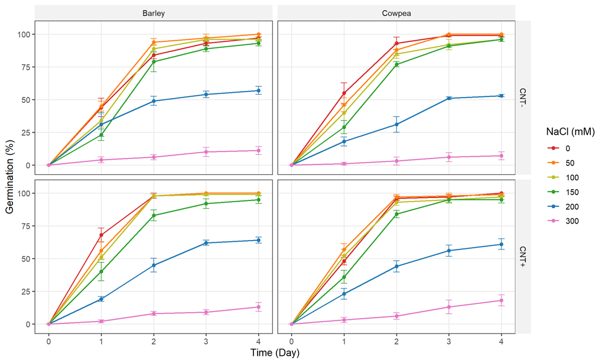

```r
nacl_pal <- c(
  "0"   = "#d62728",
  "50"  = "#ff7f0e",
  "100" = "#bcbd22",
  "150" = "#2ca02c",
  "200" = "#1f77b4",
  "300" = "#e377c2"
)

p_germ <- ggplot(germ_summary,
                 aes(x = day, y = mean_pct,
                     colour = nacl, group = nacl)) +
  geom_errorbar(aes(ymin = mean_pct - se_pct,
                    ymax = mean_pct + se_pct),
                width = 0.12, linewidth = 0.4) +
  geom_line(linewidth = 0.7) +
  geom_point(size = 1.6) +
  facet_grid(cnt ~ species) +
  scale_colour_manual(values = nacl_pal, name = "NaCl (mM)") +
  scale_y_continuous(limits = c(-2, 105),
                     breaks = c(0, 25, 50, 75, 100)) +
  labs(x = "Time (Day)", y = "Germination (%)") +
  theme(legend.position = "right")

p_germ
```

```r
ggsave("figures/germination_curves.png", p_germ,
       width = 10, height = 6, dpi = 150, bg = "white")
```

Up to 150 mM NaCl, both species reach ~90 – 95 % germination by Day 2 – 3. At 200 mM the curves plateau around 50 – 60 % (cowpea slightly lower than barley), and at 300 mM germination is essentially abolished. CNT+ panels show small but consistent upward shifts at the moderate-to- high salt levels — the priming effect on germination timing.

## Univariate response: violin + box composite

The headline figure: violin (full distribution shape) overlaid with a narrow boxplot (median + IQR), faceted by species, panelled by response variable.

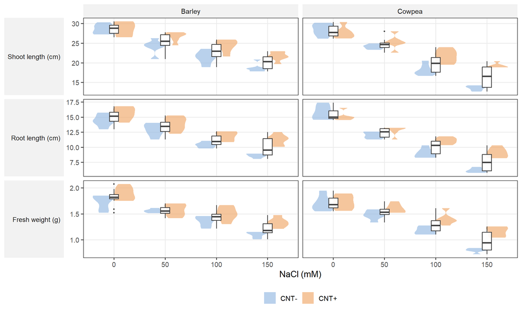

```r
long <- df %>%
  select(species, nacl, cnt,
         shoot_length_cm, root_length_cm, fresh_weight_g) %>%
  pivot_longer(-c(species, nacl, cnt),
               names_to = "variable", values_to = "value")

label_lookup <- c(
  shoot_length_cm  = "Shoot length (cm)",
  root_length_cm   = "Root length (cm)",
  fresh_weight_g   = "Fresh weight (g)"
)
long$variable <- factor(long$variable,
                        levels = names(label_lookup),
                        labels = label_lookup)

p_violin <- ggplot(long,
       aes(x = nacl, y = value, fill = cnt)) +
  geom_violin(position = position_dodge(0.8),
              width = 0.85, alpha = 0.65, colour = NA, scale = "width") +
  geom_boxplot(position = position_dodge(0.8),
               width = 0.18, outlier.size = 0.6,
               colour = "grey25", fill = "white", alpha = 0.9) +
  facet_grid(variable ~ species, scales = "free_y", switch = "y") +
  scale_fill_manual(values = c("CNT-" = "#94b8e2", "CNT+" = "#f0a868"),
                    name = NULL) +
  labs(x = "NaCl (mM)", y = NULL) +
  theme(strip.placement = "outside",
        strip.text.y.left = element_text(angle = 0, hjust = 1, size = 9),
        panel.spacing.y = unit(0.4, "lines"))

p_violin
```

```r
ggsave("figures/violin_panel.png", p_violin,
       width = 10, height = 6, dpi = 150, bg = "white")
```

The signal is clear: growth falls with NaCl and the orange (CNT+) violins sit above the blue (CNT–) ones at high salt, with cowpea showing a steeper drop than barley.

## ANOVA across all responses

Three-way ANOVA `species × NaCl × CNT` on every measured response. The expected pattern: main effects of species, NaCl and CNT on growth; the same plus stronger NaCl effects on the stress markers; and a NaCl × CNT interaction wherever CNT priming partially rescues (or amplifies) the NaCl effect.

```r
all_vars <- c(
  "shoot_length_cm", "root_length_cm", "fresh_weight_g",
  "shoot_root_axis_weight_mg",
  "MDA_nmol_gFW", "H2O2_umol_gFW",
  "SOD_U_mg", "CAT_U_mg", "APX_U_mg", "proline_umol_gFW"
)

stars <- function(p) {
  ifelse(is.na(p), "",
    ifelse(p < 0.001, "***",
    ifelse(p < 0.01,  "**",
    ifelse(p < 0.05,  "*",
    ifelse(p < 0.10,  ".", "")))))
}

run_aov <- function(v) {
  fit <- aov(reformulate("species * nacl * cnt", response = v),
             data = df)
  td  <- broom::tidy(fit)
  td  <- td[td$term != "Residuals", ]
  td$cell <- sprintf("F=%.1f%s",
                     td$statistic, stars(td$p.value))
  setNames(td$cell, td$term)
}

aov_mat <- t(sapply(all_vars, run_aov))
aov_df  <- data.frame(Variable = rownames(aov_mat),
                      aov_mat, check.names = FALSE,
                      row.names = NULL)

knitr::kable(aov_df,
             caption = paste("Three-way ANOVA F-statistics",
                             "(*** p<0.001, ** p<0.01, * p<0.05, . p<0.10)"))
```

Three-way ANOVA F-statistics (*** p<0.001, ** p<0.01, * p<0.05, . p<0.10)

| Variable | species | nacl | cnt | species:nacl | species:cnt | nacl:cnt | species:nacl:cnt |
| --- | --- | --- | --- | --- | --- | --- | --- |
| shoot_length_cm | F=50.9*** | F=240.7*** | F=64.6*** | F=8.2*** | F=0.3 | F=12.6*** | F=2.5. |
| root_length_cm | F=37.4*** | F=290.0*** | F=72.7*** | F=11.2*** | F=0.7 | F=10.6*** | F=2.8* |
| fresh_weight_g | F=37.2*** | F=180.2*** | F=55.3*** | F=4.5** | F=1.3 | F=5.8** | F=2.0 |
| shoot_root_axis_weight_mg | F=30.4*** | F=165.5*** | F=27.1*** | F=8.3*** | F=2.5 | F=8.1*** | F=2.7. |
| MDA_nmol_gFW | F=84.3*** | F=460.0*** | F=42.7*** | F=19.7*** | F=0.1 | F=4.7** | F=0.2 |
| H2O2_umol_gFW | F=61.2*** | F=487.1*** | F=40.0*** | F=10.4*** | F=5.3* | F=11.0*** | F=1.2 |
| SOD_U_mg | F=0.0 | F=572.8*** | F=5.7* | F=0.9 | F=0.5 | F=3.3* | F=0.4 |
| CAT_U_mg | F=2.1 | F=549.8*** | F=30.9*** | F=2.8* | F=0.8 | F=0.7 | F=1.3 |
| APX_U_mg | F=0.2 | F=284.2*** | F=4.9* | F=1.0 | F=1.1 | F=0.6 | F=0.8 |
| proline_umol_gFW | F=1.6 | F=624.2*** | F=2.0 | F=1.9 | F=5.0* | F=0.3 | F=5.4** |

## Growth × biochemistry correlations

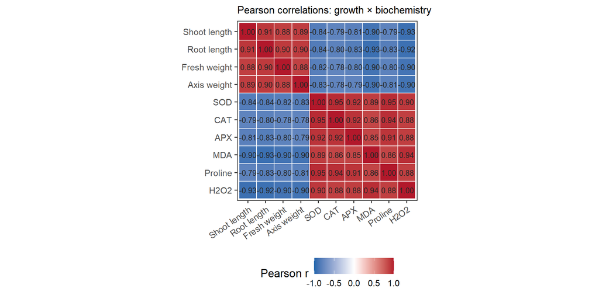

```r
growth_set <- c("shoot_length_cm", "root_length_cm",
                "fresh_weight_g", "shoot_root_axis_weight_mg")
biochem_set <- c("SOD_U_mg", "CAT_U_mg", "APX_U_mg",
                 "MDA_nmol_gFW", "proline_umol_gFW", "H2O2_umol_gFW")

cor_mat <- cor(df[, c(growth_set, biochem_set)], method = "pearson")
cor_long <- data.frame(
  V1 = rep(rownames(cor_mat), times = ncol(cor_mat)),
  V2 = rep(colnames(cor_mat), each = nrow(cor_mat)),
  r  = as.vector(cor_mat),
  stringsAsFactors = FALSE
)

# Restrict to growth (rows) × biochem (columns) panel + biochem × biochem
short_lab <- c(
  shoot_length_cm           = "Shoot length",
  root_length_cm            = "Root length",
  fresh_weight_g            = "Fresh weight",
  shoot_root_axis_weight_mg = "Axis weight",
  SOD_U_mg                  = "SOD", CAT_U_mg = "CAT",
  APX_U_mg                  = "APX", MDA_nmol_gFW = "MDA",
  proline_umol_gFW          = "Proline", H2O2_umol_gFW = "H2O2"
)
cor_long$V1 <- factor(short_lab[as.character(cor_long$V1)],
                      levels = short_lab)
cor_long$V2 <- factor(short_lab[as.character(cor_long$V2)],
                      levels = rev(short_lab))

p_corr <- ggplot(cor_long, aes(V1, V2, fill = r)) +
  geom_tile(colour = "white", linewidth = 0.4) +
  geom_text(aes(label = sprintf("%.2f", r)),
            size = 3, colour = "grey15") +
  scale_fill_gradient2(low = "#2166ac", mid = "white",
                       high = "#b2182b", midpoint = 0,
                       limits = c(-1, 1), name = "Pearson r") +
  coord_fixed() +
  labs(x = NULL, y = NULL,
       title = "Pearson correlations: growth × biochemistry") +
  theme(axis.text.x = element_text(angle = 35, hjust = 1),
        plot.title = element_text(face = "plain", size = 11),
        panel.grid = element_blank())

p_corr
```

```r
ggsave("figures/corr_heatmap.png", p_corr,
       width = 9, height = 4.5, dpi = 150, bg = "white")
```

The expected priming-hypothesis pattern is visible: growth indices correlate strongly **negatively** with MDA, H₂O₂ and proline (more salt → smaller plants and more damage), and strongly **positively** with each other; the antioxidant enzymes SOD, CAT and APX correlate positively with damage markers because both respond to NaCl. The four growth indices form a tight positive block, confirming that they are near-collinear and justifying the dimensionality reduction in the per-species PCAs that follow.

## Multivariate response: per-species PCA

One PCA per species on three **growth indices** — shoot length, root length, and shoot-root axis fresh weight. Each species gives a *correlation circle* showing which variables drive each axis, and a *treatment biplot* showing how the eight NaCl × CNT combinations separate in PC1–PC2 space.

```r
growth_vars  <- c("shoot_length_cm", "root_length_cm",
                  "shoot_root_axis_weight_mg")
biochem_vars <- c("SOD_U_mg", "CAT_U_mg", "APX_U_mg",
                  "MDA_nmol_gFW", "proline_umol_gFW", "H2O2_umol_gFW")

run_species_pca <- function(species_name, vars = growth_vars) {
  sub <- df[df$species == species_name, ]
  res <- PCA(sub[, vars], scale.unit = TRUE,
             graph = FALSE, ncp = 3)
  list(sub = sub, res = res, eig = res$eig)
}

plot_treatment_biplot <- function(pca_obj, species_name) {
  sub <- pca_obj$sub
  res <- pca_obj$res
  eig <- pca_obj$eig

  ind <- as.data.frame(res$ind$coord[, 1:2])
  names(ind) <- c("Dim1", "Dim2")
  ind$nacl <- sub$nacl
  ind$cnt  <- sub$cnt
  ind$group <- interaction(sub$nacl, sub$cnt, sep = " / ",
                           lex.order = TRUE)
  levels(ind$group) <- gsub("^", "NaCl ", levels(ind$group))

  vc <- as.data.frame(res$var$coord[, 1:2])
  names(vc) <- c("Dim1", "Dim2")
  scale_factor <- min(
    diff(range(ind$Dim1)) / diff(range(vc$Dim1)),
    diff(range(ind$Dim2)) / diff(range(vc$Dim2))
  ) * 0.85
  vc$Dim1s   <- vc$Dim1 * scale_factor
  vc$Dim2s   <- vc$Dim2 * scale_factor
  vc$varname <- rownames(vc)

  pal <- RColorBrewer::brewer.pal(8, "Paired")

  ggplot(ind, aes(Dim1, Dim2)) +
    geom_hline(yintercept = 0, linetype = "dashed", colour = "grey70") +
    geom_vline(xintercept = 0, linetype = "dashed", colour = "grey70") +
    stat_ellipse(aes(colour = group, fill = group, linetype = cnt,
                     group = group),
                 geom = "polygon", alpha = 0.15, level = 0.68,
                 linewidth = 0.6) +
    geom_point(aes(colour = group, shape = cnt),
               size = 2.2, alpha = 0.85) +
    scale_colour_manual(values = pal, name = "Treatment") +
    scale_fill_manual(values  = pal, name = "Treatment") +
    scale_linetype_manual(values = c("CNT-" = "solid",
                                     "CNT+" = "dashed"),
                          name = NULL) +
    scale_shape_manual(values = c("CNT-" = 16, "CNT+" = 17),
                       name = NULL) +
    guides(
      colour   = guide_legend(override.aes = list(
        linetype = rep(c("solid", "dashed"), 4),
        shape    = rep(c(16, 17), 4)
      )),
      fill     = "none",
      linetype = "none",
      shape    = "none"
    ) +
    labs(title = species_name,
         x = sprintf("PC1 (%.1f%%)", eig[1, 2]),
         y = sprintf("PC2 (%.1f%%)", eig[2, 2])) +
    theme(legend.position = "right",
          plot.title = element_text(face = "plain", size = 12))
}

plot_var_circle <- function(pca_obj, species_name) {
  eig <- pca_obj$eig
  fviz_pca_var(pca_obj$res, axes = c(1, 2),
               col.var = "contrib", repel = TRUE,
               gradient.cols = c("#3b528b", "#f0a868", "#d62728")) +
    labs(title = species_name,
         x = sprintf("PC1 (%.1f%%)", eig[1, 2]),
         y = sprintf("PC2 (%.1f%%)", eig[2, 2])) +
    theme(plot.title = element_text(face = "plain", size = 12))
}
```

### Barley and Cowpea

```r
pca_b <- run_species_pca("Barley")
pca_c <- run_species_pca("Cowpea")

cat("Barley eigenvalues:\n");  print(round(pca_b$eig[1:3, ], 2))
```

```
## Barley eigenvalues:
```

```
##        eigenvalue percentage of variance cumulative percentage of variance
## comp 1       2.66                  88.74                             88.74
## comp 2       0.19                   6.25                             94.99
## comp 3       0.15                   5.01                            100.00
```

```r
cat("\nCowpea eigenvalues:\n"); print(round(pca_c$eig[1:3, ], 2))
```

```
##
## Cowpea eigenvalues:
```

```
##        eigenvalue percentage of variance cumulative percentage of variance
## comp 1       2.85                  95.02                             95.02
## comp 2       0.10                   3.25                             98.26
## comp 3       0.05                   1.74                            100.00
```

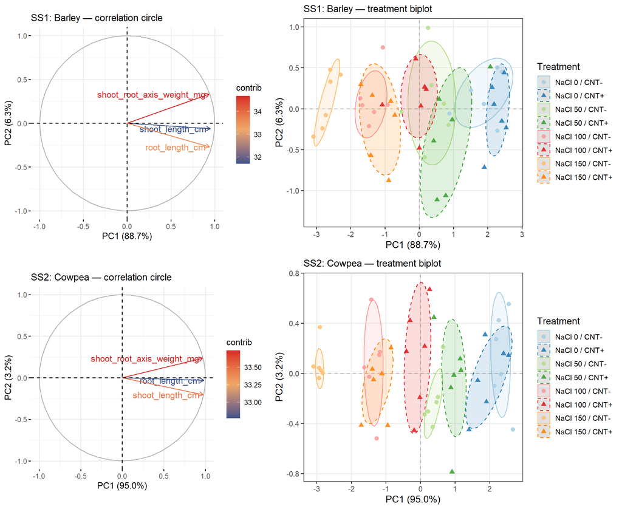

```r
p_b_var <- plot_var_circle(pca_b,       "SS1: Barley — correlation circle")
p_b_bip <- plot_treatment_biplot(pca_b, "SS1: Barley — treatment biplot")
p_c_var <- plot_var_circle(pca_c,       "SS2: Cowpea — correlation circle")
p_c_bip <- plot_treatment_biplot(pca_c, "SS2: Cowpea — treatment biplot")

g <- gridExtra::arrangeGrob(p_b_var, p_b_bip,
                            p_c_var, p_c_bip,
                            ncol = 2, widths = c(1, 1.3))
grid::grid.newpage(); grid::grid.draw(g)
```

```r
ggsave("figures/pca_ss1_ss2.png", g,
       width = 11, height = 9, dpi = 150, bg = "white")
```

### Per-species PCA on biochemistry (SOD, CAT, APX, MDA, proline, H₂O₂)

The same per-species PCA layout, this time on the six stress-response biochemistry variables. Whereas the growth-index PCA above separated treatments along a single salt-stress axis, the biochemistry PCA can distinguish the **direction** of the response — antioxidant enzymes (rising under both salt and CNT priming) versus damage markers (rising under salt but suppressed by CNT priming).

```r
pca_b2 <- run_species_pca("Barley", biochem_vars)
pca_c2 <- run_species_pca("Cowpea", biochem_vars)

cat("Barley biochem eigenvalues:\n");  print(round(pca_b2$eig[1:3, ], 2))
```

```
## Barley biochem eigenvalues:
```

```
##        eigenvalue percentage of variance cumulative percentage of variance
## comp 1       5.59                  93.21                             93.21
## comp 2       0.15                   2.52                             95.73
## comp 3       0.11                   1.88                             97.61
```

```r
cat("\nCowpea biochem eigenvalues:\n"); print(round(pca_c2$eig[1:3, ], 2))
```

```
##
## Cowpea biochem eigenvalues:
```

```
##        eigenvalue percentage of variance cumulative percentage of variance
## comp 1       5.59                  93.19                             93.19
## comp 2       0.16                   2.67                             95.86
## comp 3       0.10                   1.64                             97.50
```

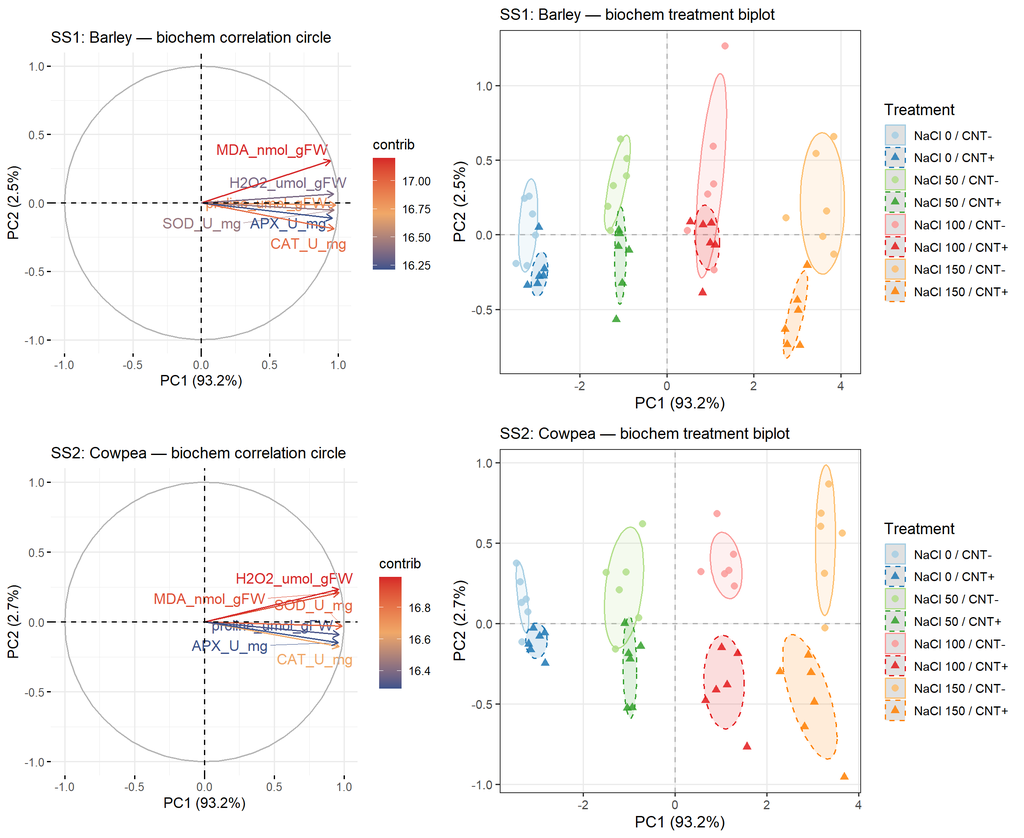

```r
p_b2_var <- plot_var_circle(pca_b2,       "SS1: Barley — biochem correlation circle")
p_b2_bip <- plot_treatment_biplot(pca_b2, "SS1: Barley — biochem treatment biplot")
p_c2_var <- plot_var_circle(pca_c2,       "SS2: Cowpea — biochem correlation circle")
p_c2_bip <- plot_treatment_biplot(pca_c2, "SS2: Cowpea — biochem treatment biplot")

g2 <- gridExtra::arrangeGrob(p_b2_var, p_b2_bip,
                             p_c2_var, p_c2_bip,
                             ncol = 2, widths = c(1, 1.3))
grid::grid.newpage(); grid::grid.draw(g2)
```

```r
ggsave("figures/pca_ss1_ss2_biochem.png", g2,
       width = 11, height = 9, dpi = 150, bg = "white")
```